# Notas de Clase: Análisis factorial I

¿La prueba mide una habilidad o dos? El encargo del empleador que contrata técnicos

Estadística Multidimensional · Universidad Distrital Francisco José de Caldas

Sábado 24 de octubre de 2026

# 1 Introducción: el encargo

Esta vez el cliente no es una institución educativa. Es **una empresa que contrata técnicos y tecnólogos** —mantenimiento, sistemas, atención al cliente— y que pide la prueba Saber como requisito en sus convocatorias. Su jefe de selección nos escribe:

> *«Estoy armando dos perfiles de cargo: uno analítico, para los puestos técnicos, y uno comunicativo, para los de atención. Quiero usar la prueba para escoger. ¿La prueba mide una habilidad cuantitativa y otra verbal, o todo es lo mismo?»*

La pregunta de hoy:

> **¿Cuántas habilidades hay detrás de los cinco puntajes, y qué parte de cada puntaje es habilidad compartida y qué parte es propia de ese módulo?**

La sesión pasada resumimos los cinco módulos y vimos que el mejor resumen de un número es el global. Hoy la pregunta es otra: no *cómo resumir*, sino **qué hay detrás**.

# 2 Objetivos de aprendizaje

Al terminar la sesión, cada estudiante debe poder:

1. Explicar la idea de **parte común y parte propia** de una variable.
2. Leer una **carga** y decir qué tanto pesa la habilidad común en un módulo.
3. Comprobar si **una sola habilidad alcanza** para explicar cómo se mueven juntos los módulos.
4. Decir **en qué se diferencia** este análisis del resumen de la sesión pasada.
5. **Traducir el resultado a la decisión del cliente**: cuántos perfiles de cargo sostiene la prueba.

# 3 La base con la que llegamos

La misma limpieza de las sesiones pasadas.

```r
saber <- read.csv("PruebaSaber1.csv", sep = ";", fileEncoding = "latin1",
                  stringsAsFactors = FALSE)

s <- saber |>
  transmute(
    cuantitativo = MOD_RAZONA_CUANTITAT_PUNT,
    lectura      = MOD_LECTURA_CRITICA_PUNT,
    ciudadanas   = MOD_COMPETEN_CIUDADA_PUNT,
    ingles       = MOD_INGLES_PUNT,
    escritura    = MOD_COMUNI_ESCRITA_PUNT,
    global       = PUNT_GLOBAL,
    estrato      = FAMI_ESTRATOVIVIENDA
  )
s$id <- seq_len(nrow(s))

modulos <- c("cuantitativo", "lectura", "ciudadanas", "ingles", "escritura")
etiqueta <- c(cuantitativo = "cuantitativo", lectura = "lectura", ciudadanas = "ciudadanas",
              ingles = "inglés", escritura = "escritura")

s <- s[s$estrato != "Empleado obrero u operario", ]          # fila corrida
s$ingles[s$ingles == 0] <- NA                                 # no presentaron inglés
for (m in modulos) s[[m]][s$id %in% c(671, 614) & s[[m]] == 0] <- NA   # filas 671 y 614

sc <- s[complete.cases(s[modulos]), ]
X  <- sc[modulos]
nrow(X)
```

```
## [1] 9907
```

Trabajamos con los 9 907 estudiantes que tienen los cinco módulos.

# 4 Lo que ya sabíamos

La sesión pasada dejó dos pistas:

- La primera componente guardaba **52,9 de cada 100** partes de la información, y era el nivel general.
- **Escritura e inglés iban solos**: la segunda y la tercera componente eran, cada una, casi un solo módulo.

La pregunta que quedó abierta es si esas dos cosas que «van solas» son **habilidades distintas** o simplemente **parte propia de cada módulo**: lo que mide ese examen y ningún otro.

# 5 La idea: parte común y parte propia

> 📐 **La matemática, enunciada.** Cada módulo, puesto en escala estándar, se parte en dos:

> $$\text{módulo} = \text{carga} \times
> \text{habilidad común} + \text{parte propia}$$

> Y su variación se reparte igual:

> $$1 = \text{carga}^2 + \text{varianza de
> la parte propia}$$

> **En palabras:** la **habilidad común** es lo que los cinco módulos comparten; nadie la ve directamente, se deduce de cómo se mueven juntos. La **carga** dice qué tanto pesa esa habilidad en cada módulo. La **carga al cuadrado** es qué parte de las diferencias entre estudiantes en ese módulo viene de la habilidad común. Lo que sobra es **propio del módulo**: lo que ese examen mide y ningún otro, más el error de medición.

Aquí está la diferencia con la sesión pasada: el resumen de la sesión 3 metía **todo** en la componente, incluida la parte propia. Este análisis **la separa**.

## 5.1 ¿Hay algo común que buscar?

Antes de buscar una habilidad compartida, conviene comprobar que los módulos compartan algo. Si cada módulo fuera independiente, no habría nada que buscar.

```r
kmo <- KMO(X)
round(c(general = kmo$MSA, kmo$MSAi), 2)
```

```
##      general cuantitativo      lectura   ciudadanas       ingles    escritura
##         0.80         0.82         0.74         0.77         0.87         0.90
```

> 📋 **Describir:** el índice general da 0,80, y por módulo va de 0,74 a 0,90. Este índice va de 0 a 1 y mide qué tanto de lo que se mueve junto se puede atribuir a algo compartido; por encima de 0,7 se considera bueno.

> 🔎 **Analizar:** los cinco módulos comparten lo suficiente para que tenga sentido buscar habilidades comunes. **Decisión:** seguimos. (El índice se llama KMO; no hace falta recordarlo.)

# 6 Una sola habilidad

Empezamos por lo más simple: **una habilidad común** detrás de los cinco.

```r
f1 <- fa(X, nfactors = 1, fm = "ml")
reparto <- data.frame(modulo = modulos,
                      carga  = as.numeric(f1$loadings[, 1]),
                      comun  = as.numeric(f1$communality),
                      propia = as.numeric(f1$uniquenesses))
reparto$carga  <- round(reparto$carga, 2)
reparto$comun  <- round(100 * reparto$comun, 1)
reparto$propia <- round(100 * reparto$propia, 1)
reparto
```

| modulo | carga | comun | propia |
| --- | --- | --- | --- |
| cuantitativo | 0.66 | 43.3 | 56.7 |
| lectura | 0.84 | 70.2 | 29.8 |
| ciudadanas | 0.75 | 55.8 | 44.2 |
| ingles | 0.54 | 28.9 | 71.1 |
| escritura | 0.39 | 15.2 | 84.8 |

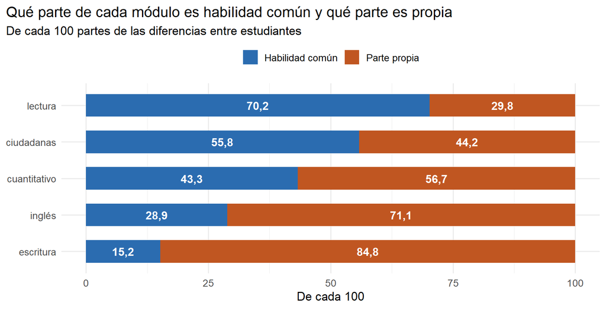

```r
reparto |>
  select(modulo, `Habilidad común` = comun, `Parte propia` = propia) |>
  pivot_longer(-modulo) |>
  mutate(modulo = factor(etiqueta[modulo], levels = rev(etiqueta[reparto$modulo[order(-reparto$comun)]])),
         name = factor(name, levels = c("Parte propia", "Habilidad común"))) |>
  ggplot(aes(value, modulo, fill = name)) +
  geom_col(width = 0.62) +
  geom_text(aes(label = coma(value)), position = position_stack(vjust = 0.5),
            color = "white", fontface = "bold", size = 4.2) +
  scale_fill_manual(values = c("Habilidad común" = "#2B6CB0", "Parte propia" = "#C05621"),
                    breaks = c("Habilidad común", "Parte propia"), name = NULL) +
  scale_x_continuous(labels = function(x) coma(x, 0)) +
  labs(title = "Qué parte de cada módulo es habilidad común y qué parte es propia",
       subtitle = "De cada 100 partes de las diferencias entre estudiantes",
       x = "De cada 100", y = NULL) +
  theme(legend.position = "top")
```

> 📋 **Describir:** en lectura, 70,2 de cada 100 partes de las diferencias entre estudiantes vienen de la habilidad común. En ciudadanas, 55,8; en cuantitativo, 43,3. En inglés baja a 28,9 y en escritura a 15,2: **84,8 de cada 100 partes de escritura son propias.**

> 🔎 **Analizar:** la habilidad común pesa mucho en lectura y ciudadanas, y casi nada en escritura. Por eso escritura «iba sola» en la sesión pasada: **no es que mida otra habilidad compartida; es que casi todo lo que mide es suyo**. Lo mismo, en menor grado, inglés. **Decisión:** para el empleador, escritura e inglés no se pueden deducir de los otros tres módulos; si le importan, hay que mirarlos aparte.

# 7 ¿Alcanza con una habilidad?

La prueba de fuego: si de verdad hay una sola habilidad detrás, **ella sola tiene que explicar por qué los módulos se mueven juntos**.

> 📐 **La matemática, enunciada.** Con una sola habilidad común, lo que se mueven juntos dos módulos debería ser el producto de sus cargas:

> $$\text{correlación}(i, j) \approx
> \text{carga}_i \times \text{carga}_j$$

> **En palabras:** dos módulos van juntos **solo porque comparten la habilidad**. Si hay otra cosa que los une —una segunda habilidad—, la cuenta no va a cuadrar.

```r
R <- cor(X)
L <- as.numeric(f1$loadings[, 1]); names(L) <- modulos
ejemplo <- c(observada = round(R["lectura", "ciudadanas"], 3),
             producto_de_cargas = round(unname(L["lectura"] * L["ciudadanas"]), 3))
ejemplo
```

```
##          observada producto_de_cargas
##              0.635              0.626
```

```r
error <- R - outer(L, L); diag(error) <- 0
c(error_maximo = round(max(abs(error)), 3))
```

```
## error_maximo
##        0.045
```

```r
donde <- which(abs(error) == max(abs(error)), arr.ind = TRUE)[1, ]
c(pareja_con_mas_error = paste(etiqueta[modulos[donde]], collapse = " y "))
```

```
##    pareja_con_mas_error
## "inglés y cuantitativo"
```

> 📋 **Describir:** lectura y ciudadanas van juntas 0,635; el producto de sus cargas da 0,626. Revisando las diez parejas de módulos, el error más grande es 0,045, entre cuantitativo e inglés.

> 🔎 **Analizar:** **una sola habilidad reproduce casi perfectamente cómo se mueven juntos los cinco módulos.** No queda nada importante sin explicar que pida una segunda habilidad. **Decisión:** la respuesta al jefe de selección empieza a ser clara: la prueba no separa una habilidad cuantitativa de una verbal.

# 8 ¿Y si le pedimos dos?

El cliente quería dos perfiles. Probemos con dos habilidades y veamos qué ganamos.

```r
f2 <- fa(X, nfactors = 2, fm = "ml", rotate = "oblimin")
c(comun_con_una  = round(100 * sum(f1$communality) / 5, 1),
  comun_con_dos  = round(100 * sum(f2$communality) / 5, 1),
  lectura_comun_con_dos = round(100 * unname(f2$communality["lectura"]), 1),
  las_dos_van_juntas    = round(f2$Phi[1, 2], 2))
```

```
##         comun_con_una         comun_con_dos lectura_comun_con_dos
##                 42.70                 49.20                 99.50
##    las_dos_van_juntas
##                  0.79
```

```r
round(unclass(f2$loadings), 2)
```

```
##               ML2   ML1
## cuantitativo 0.60  0.08
## lectura      0.01  0.99
## ciudadanas   0.53  0.22
## ingles       0.67 -0.10
## escritura    0.42 -0.02
```

> 📋 **Describir:** con una habilidad, la parte común es 42,7 de cada 100; con dos, 49,2. La segunda habilidad cae **casi entera sobre lectura**, que queda con 99,5 de cada 100 como común. Y las dos habilidades van juntas 0,79.

> 🔎 **Analizar:** la segunda habilidad no es «verbal» frente a «cuantitativa»: es **lectura sola**. Una habilidad que se reduce a un módulo no es una habilidad nueva: es el módulo. Y dos habilidades que van juntas 0,79 son casi la misma. **Decisión:** la prueba no sostiene dos perfiles de cargo. El lunes veremos cómo se gira esta solución para intentar nombrarla, y por qué tampoco así aparece la separación que el cliente esperaba.

# 9 ¿En qué se diferencia del resumen de la sesión 3?

```r
pca <- prcomp(X, scale. = TRUE)
c(el_resumen_guardaba = round(100 * pca$sdev[1]^2 / 5, 1),
  la_habilidad_comun_explica = round(100 * sum(f1$communality) / 5, 1))
```

```
##        el_resumen_guardaba la_habilidad_comun_explica
##                       52.8                       42.7
```

|  | Resumen (sesión 3) | Habilidad común (hoy) |
| --- | --- | --- |
| Qué busca | El número que más separa a los estudiantes | Lo que los módulos **comparten** |
| Qué hace con la parte propia | La mete en el resumen | La **separa** y la reporta aparte |
| Cuánto guarda aquí | 52,8 de cada 100 | 42,7 de cada 100 |
| Pregunta de negocio | ¿Con qué número ordeno? | ¿Cuántas habilidades hay, y qué es propio de cada examen? |

> 📋 **Describir:** con los módulos en escala estándar, como aquí, el resumen guardaba 52,8 de cada 100 (52,9 sin estandarizar, como en la sesión 3); la habilidad común explica 42,7.

> 🔎 **Analizar:** la diferencia es justamente la parte propia que el resumen se llevaba de paso. **Ni uno es mejor que el otro**: responden preguntas distintas. **Decisión:** si el cliente quiere ordenar, resumen; si quiere saber qué habilidades hay para armar perfiles, habilidad común.

# 10 El costo para el empleador

Traducimos a candidatos. Supongamos que la empresa contrata al 20 % más alto en la **habilidad común**.

```r
f1s <- fa(X, nfactors = 1, fm = "ml", scores = "regression")
habilidad <- f1s$scores[, 1]
alto <- function(v) v >= quantile(v, 0.80)
costo <- lapply(c("escritura", "ingles", "cuantitativo", "lectura"), function(m) {
  mejores <- alto(sc[[m]]); elegidos <- alto(habilidad)
  data.frame(modulo = m, mejores_del_modulo = sum(mejores),
             contratados = sum(mejores & elegidos), se_escapan = sum(mejores & !elegidos))
}) |> bind_rows()
costo$de_cada_100 <- round(100 * costo$se_escapan / costo$mejores_del_modulo, 1)
costo
```

| modulo | mejores_del_modulo | contratados | se_escapan | de_cada_100 |
| --- | --- | --- | --- | --- |
| escritura | 2046 | 821 | 1225 | 59.9 |
| ingles | 2001 | 1088 | 913 | 45.6 |
| cuantitativo | 2027 | 1214 | 813 | 40.1 |
| lectura | 2078 | 1598 | 480 | 23.1 |

```r
c(habilidad_y_global_van_juntos = round(cor(habilidad, sc$global), 3))
```

```
## habilidad_y_global_van_juntos
##                         0.965
```

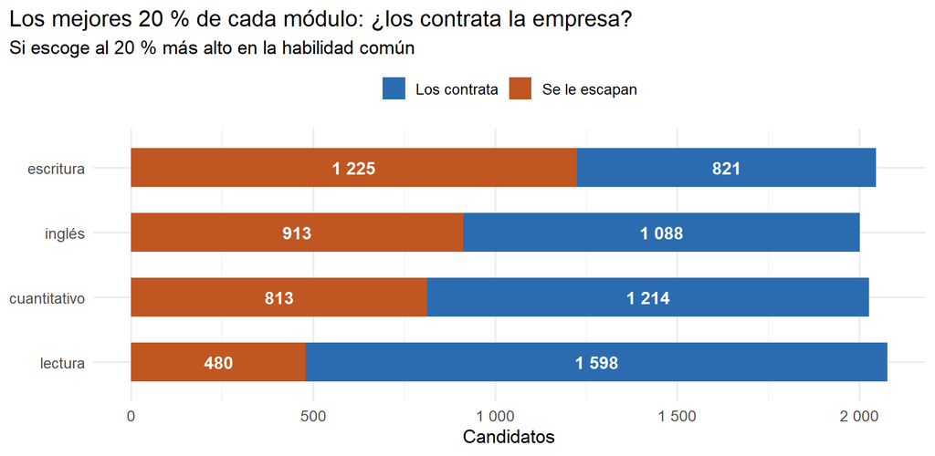

```r
costo |>
  select(modulo, `Los contrata` = contratados, `Se le escapan` = se_escapan) |>
  pivot_longer(-modulo) |>
  mutate(modulo = factor(etiqueta[modulo], levels = rev(etiqueta[costo$modulo]))) |>
  ggplot(aes(value, modulo, fill = name)) +
  geom_col(width = 0.6) +
  geom_text(aes(label = miles(value)), position = position_stack(vjust = 0.5),
            color = "white", fontface = "bold", size = 4.2) +
  scale_fill_manual(values = c("#2B6CB0", "#C05621"), name = NULL) +
  scale_x_continuous(labels = miles) +
  labs(title = "Los mejores 20 % de cada módulo: ¿los contrata la empresa?",
       subtitle = "Si escoge al 20 % más alto en la habilidad común",
       x = "Candidatos", y = NULL) +
  theme(legend.position = "top")
```

> 📋 **Describir:** de los 2 046 mejores en escritura, contratar por la habilidad común deja por fuera a 1 225: 59,9 de cada 100. En inglés se escapan 913. En lectura, donde la habilidad común pesa más, solo 480.

> 🔎 **Analizar:** es la parte propia en candidatos: **el que mejor escribe no es necesariamente el de mayor habilidad común**, y la empresa no lo va a encontrar si escoge por ella. **Decisión:** para un cargo de atención al cliente, donde escribir bien importa, el requisito tiene que ser el módulo de escritura, no el puntaje general.

# 11 Qué no es una habilidad común

- **No es algo que se observe.** Se deduce de cómo se mueven juntos los módulos. Nadie la midió.
- **No prueba que exista una capacidad en la cabeza del estudiante.** Dice que los puntajes se comportan como si la hubiera. Una buena escuela, más horas de estudio o el nivel del hogar también mueven todos los módulos a la vez.
- **La parte propia no es «error».** En escritura es casi todo lo que el módulo mide: es información valiosa, solo que no se comparte con los demás.

# 12 La puerta a lo que viene

| Lo que vimos hoy | La pregunta que queda | Dónde se responde |
| --- | --- | --- |
| Con dos habilidades, la segunda cae sobre lectura | Si **giramos** la solución, ¿aparecen dos habilidades con nombre? | **Lun 26 oct** · Factorial II: rotación |
| Una habilidad alcanza con cinco módulos | ¿Cuántas habilidades se pueden sacar como máximo con cinco módulos? | **Lun 26 oct** |

# 13 Actividad práctica

Con **el dataset de su equipo** y **el cliente de su caso de negocio**:

1. Escojan entre 4 y 10 variables numéricas que crean que comparten algo. Calculen `KMO()`.
2. Corran `fa(datos, nfactors = 1, fm = "ml")`. Hagan la gráfica de parte común y parte propia.
3. ¿Qué variable es casi toda propia? ¿Qué significa eso para su cliente?
4. Comprueben si una habilidad alcanza: comparen las correlaciones con el producto de las cargas.
5. Prueben con dos. ¿La segunda es una habilidad con sentido, o es una sola variable?

# 14 Preguntas conceptuales

1. ¿Qué diferencia hay entre la parte común y la parte propia de un módulo?
2. Escritura tiene 15 de cada 100 partes comunes. ¿Significa que el módulo de escritura está mal hecho? ¿Por qué?
3. Si la correlación entre dos módulos es casi igual al producto de sus cargas, ¿qué nos dice eso sobre cuántas habilidades hay?
4. La segunda habilidad cae casi entera sobre lectura. ¿Por qué no la llamamos «habilidad verbal»?
5. ¿Por qué el resumen de la sesión 3 guardaba más de cada 100 que la habilidad común de hoy?
6. ¿Cuál de estas afirmaciones es correcta? **(a)** La habilidad común se mide directamente en la prueba. **(b)** La carga al cuadrado es la parte de las diferencias en un módulo que viene de la habilidad común. **(c)** La parte propia es siempre error de medición. **(d)** Si hay dos habilidades, siempre son independientes.

# 15 Conclusión: lo que le entregamos al cliente

Al jefe de selección le respondemos:

- **La prueba mide una sola habilidad común, no dos.** Una habilidad reproduce casi perfectamente cómo se mueven juntos los cinco módulos.
- **Pero esa habilidad no lo es todo.** Pesa mucho en lectura y ciudadanas, y casi nada en escritura: 85 de cada 100 partes de escritura son propias del módulo. Inglés también tiene mucho propio.
- **En candidatos:** si contrata por la habilidad general, se le escapan 6 de cada 10 de los mejores en escritura.
- **La decisión:** un perfil con la habilidad general para ordenar, y **escritura e inglés como requisitos aparte** para los cargos donde importan. La prueba no sostiene un perfil «analítico» y otro «comunicativo».

La técnica de hoy se llama **análisis factorial**. Lo que hicimos fue separar lo que los módulos comparten de lo que es propio de cada uno, y decirle al cliente cuántos perfiles se pueden armar con la prueba.

# 16 Próxima clase

**Lunes 26 de octubre · Análisis factorial II: rotación.**

La pregunta: *el cliente insiste en dos perfiles; si giramos la solución de dos habilidades para que cada módulo cargue en una sola, ¿aparecen dos habilidades con nombre? ¿Y cuántas se pueden sacar como máximo con cinco módulos?*